# L18_HD_Basics slides

## AERSP 597 - Machine Learning in Aerosapce Engineering

## Lecture 18, High-Dimensional Systems: Introduction

### Instructor: Daning Huang

$$ \newcommand{\bR}{\mathbb{R}} \newcommand{\cX}{\mathcal{X}} \newcommand{\cD}{\mathcal{D}} $$

## TODAY: High-Dimensional Systems - I

- Introduction
- "Feel" high dimensionality

## Introduction

So far we have introduced a few regression models:

- Useful for establishing the functional relation between several input and output variables.
- Possible to handle dozens of variables
  - but not **millions of variables**
  - and more variables require larger dataset, which is not always available
- But in practical engineering systems, the number of variables can easily exceed millions
  - In terms of **outputs**, **inputs**, and **system/design parameters**
  - In engineering analysis (computational fluid dynamics, finite element analysis, etc.)
  - In control and dynamics (trajectory planning, uncertainty quantification, etc.)

## Curse of Dimensionality

- We have encountered one case - data sampling as number of inputs/parameters increases
  - Having $N$ points in 1-D space, to achieve the same density, $N^m$ points are needed in m-D space
  - We introduced the low-discrepancy sequence to tackle the problem.
- There are certainly more, e.g., in genereal function approximation theory
  - To approximate a function in a m-D space with error less than $\epsilon$, $(1/\epsilon)^m$ evaluations are needed
- But there are also blessings - some will be discussed today
  - A classical paper: [Donoho2000](https://citeseerx.ist.psu.edu/viewdoc/download?doi=10.1.1.329.3392&rep=rep1&type=pdf), High-Dimensional Data Analysis: The Curses and Blessings of Dimensionality

Overall this module will provide a few ways to help tackling high-dim problems:

- Dimensionality reduction
  - Obtain a compressed representation of data with significantly fewer dimensions
  - Conventional regression model will then become applicable.
- Dynamical system modeling
  - If data comes in order of time, how to utilize this information of sequence
  - In preparation for the next module (reduced-order models)

## Getting a feeling of High-dimensionality

### Example 1: Volumes

- Consider a unit cube $C$ and a unit ball $B$ in a $\bR^n$ space. What is the ratio $r$ between the volumes of $B$ and $C$?
  - The unit "cube" always has a "volume" of 1, regardless of dimension; so the question is really what is the volume of the unit ball.

In general, the volumes of a cube and a ball in $\bR^n$ are, respectively, $$ \mathrm{Vol}(C) = (2R)^n,\quad \mathrm{Vol}(B) = \frac{\pi^{n/2}}{\Gamma(n/2+1)}R^n $$ where $\Gamma$ is the Gamma function (i.e., $\Gamma(n)=(n-1)!$). Then the ratio decays **exponentially** $$ r = \frac{\pi^{n/2}}{2^n\Gamma(n/2+1)} $$

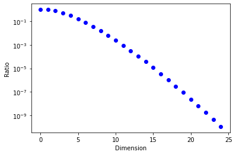

```python
ns = np.arange(25)
rs = np.pi**(ns/2) / gamma(ns/2+1) / 2**ns
plt.semilogy(ns, rs, 'bo')
plt.xlabel('Dimension')
_=plt.ylabel('Ratio')
```

### Example 2: Distribution in unit ball

- Now we continue to look at this unit ball in $\bR^n$. Suppose we randomly and **uniformly** sample some points $\{x_i\}_{i=1}^N$ in this ball, will they be
  1. Concentrated at the center, i.e. $||x_i||\approx 0$?
  2. Mostly near the boundary, i.e. $||x_i||\approx 1$?
  3. Uniformly distributed, i.e. distribution of $||x_i||$ is uniform?

Thinking in a "polar" coordinate system, the probability of $||x_i||<d$ should be equal to $$ \frac{\mbox{Volume of Ball of Radius }d}{\mbox{Volume of Unit Ball}} $$ so $P(||x_i||<d)=d^n$

Then, what is the probability $P(d)$ that all the points are at least of distance $d$ away from the origin (i.e., center of ball)?

This is equivalent to $$ P(d) = P(\forall ||x_i|| \geq d) = \prod_{i=1}^N \left[ 1-P(||x_i||< d) \right] = (1-d^n)^N $$ Now that $d<1$ and $n$ is large, so $d^n\approx 0$ and $P(d)\approx 1$.

For example, when $n=20$, $N=500$, $P(0.72)\approx 0.5$, so

> In a unit ball in $\bR^{20}$ and 500 uniformly distributed points, it is **50%** chance that all the points are at least 0.72 (!) away from the origin.

### Example 3: Gaussian distribution

- Consider $N$ points $\{x_i\}_{i=1}^N$ sampled from a unit Gaussian distribution in $\bR^n$. How are the lengths of these sample points distributed?
  1. Something close to 0
  2. A non-trivial nonzero value

> Even though intuitively Gaussians tend to concentrate at the mean (or the origin if mean=0) ...

First, the length of one sample follows the well-known Chi-squared distribution, i.e. $$ \chi_n^2 \equiv \sum_{i=1}^n x_i^2 = ||x||^2 $$ And $\mathbb{E}(\chi_n^2)=n$ - so on average the length is $\sqrt{n}$.

- In other words, high-dimensional Gaussian variables, e.g. in $\bR^n$, mostly reside on a spherical **shell** of radius $\sqrt{n}$.
- New intuition
  - Near center, the value of PDF is high; however, in high-dim, the volume near center is small. So the actual probability of having a point near center is low
  - Very away from center, the volume is indeed large, but Gaussian PDF decay exponentially. So the probability of having a very distant point is also low
  - As a result, the points will distribute over a band (in terms of their length/radius)
- Some more in-depth derivations [here](https://anmolg.me/post/high-dimensional-normal/)
- This called **concentration of measure**, see [Donoho2000] for more details

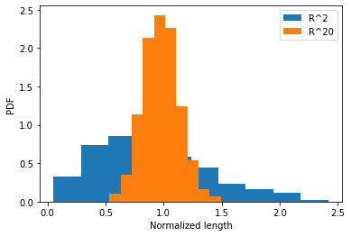

```python
Ns = 1000     # Numerical verification over 1000 samples of unit Gaussian from R^2 and R^20
S2 = np.random.randn(Ns,2)
Sh = np.random.randn(Ns,20)
d2 = np.linalg.norm(S2, axis=1) / np.sqrt(2)   # Normalize the lengths, so they should be around 1
dh = np.linalg.norm(Sh, axis=1) / np.sqrt(20)

plt.hist(d2, density=True, label='R^2')
plt.hist(dh, density=True, label='R^20')
plt.legend()
plt.xlabel('Normalized length')
_=plt.ylabel('PDF')
```

### Example 4: Orthogonality

- If we randomly sample two vectors $x$ and $y$ from a $\bR^n$ space, how likely will the two be orthogonal to each other?
  - For simplicity assume $||x||=||y||=1$; and we can just fix one vector, say $y=[1,0,\cdots,0]$
  - In 2D and 3D, it is very **unlikely**

After some derivation (some tedious integral on $\bR^n$), the PDF of the angle between $x$ and $y$ is $$ p(\theta) = \frac{\Gamma(n/2)}{\Gamma((n-1)/2)\sqrt{\pi}}\sin^{n-2}(\theta) $$ where $\theta=\cos^{-1}(x^Ty)$ and $$ P(|x^T y|\geq \epsilon) \leq \frac{1}{n\epsilon^2} $$

- i.e., $x^Ty$ is likely to be 0
- i.e., randomly chosen high-dimensional vectors are likely to be orthogonal

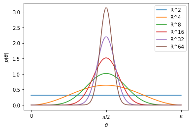

```python
tt = np.linspace(0,np.pi,100)
f, ax = plt.subplots()
for _i in [2, 4, 8, 16, 32, 64]:
    pt = gamma(_i/2) / gamma((_i-1)/2) / np.sqrt(np.pi) * np.sin(tt)**(_i-2)
    ax.plot(tt, pt, label=f'R^{_i}')
ax.legend()
ax.set_xticks([0,np.pi/2,np.pi])
ax.set_xticklabels(['0','$\pi/2$','$\pi$'])
ax.set_xlabel(r'$\theta$')
_=ax.set_ylabel(r'$p(\theta)$')
```

We can also verify numerically. Randomly generate 100 $\bR^{100}$ vectors $w_i$ and form a matrix $W=[w_1,w_2,\cdots,w_{100}]$. If the vectors are orthogonal to each other, then $$ W^TW\approx I $$ To make sure the vectors are of unit length, we chose $N(0,1/n)$.

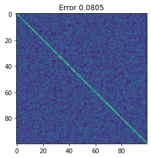

```python
n = 100
W = np.random.randn(n, n) / np.sqrt(n)
X = np.dot(W.T, W)
plt.imshow(X)
_=plt.title(f'Error {np.mean(np.abs(X - np.eye(n))):5.4f}')
```

- Connect back to the weight initialization in neural networks
- We suggested, for example, follow Uniform $U[-s,s]$ to generate the initial weights (and let bias be 0)
  - Xavier (tanh/sigmoid): $s=\sqrt{3/n}$
  - Kaiming (ReLU): $s=\sqrt{6/n}$
- We argued that in this way for the linear layer $$ h=Wx+b $$ the output $h$ would be small if the input $x$ is small; so subsequently the activation function $\sigma(h)$ is not saturated.
- Since $W$ is a high-dimensional random matrix, and for simplicity assume $W$ is square, then $$ ||h|| = ||Wx|| = \sqrt{x^TW^TWx} \approx \sqrt{x^Tx} = ||x|| $$ i.e. the norm is unchanged before and after the linear layer.

  > This is a geometrical way to make sense of the weight initialization

### Example 5: Data compression

- How much storage do we need to store (approximately) $N$ vectors in $\bR^m$?
  1. Proportional to $N$ and $m$
  2. Proportional to only $m$
  3. Proportional to only $N$
- By **Johnson–Lindenstrauss lemma**,

  > We only need $O(\log(N))$ space to store $N$ vectors, **regardless of dimension m**
- This example actually connects most of the conclusions from the previous examples

Mathematically, suppose we want to store $N$ vectors $v_1,v_2,\cdots,v_N$, $v_i\in\bR^{m}$

The J-L lemma says, one can

- Choose $n>\frac{24\log N}{\epsilon^2}$, where $\epsilon$ is an error tolerance
- Randomly generate a matrix $A\in\bR^{n\times m}$, where each entry is sampled i.i.d. from $N(0,1/n)$
  - Note that $A$ would be approximately orthogonal
- Then the vectors $v_i$ can be stored as $w_i=Av_i\in\bR^n$, for $i=1,2,\cdots,N$
  - So this is like a projection on to a subspace
- And the error is less than $\epsilon$ with a probability of $\frac{N-1}{N}$ $$ (1-\epsilon)||v_i-v_j||^2 \leq ||w_i-w_j||^2 \leq (1+\epsilon)||v_i-v_j||^2 $$
- The above result is independent of the dimension of the origional vector, and **only** depends on the number of vectors.
- And the approximation is likely to be more accurate when there are more vectors.
- The J-L lemma is the basis of the dimension reduction study; the factor $\frac{24\log N}{\epsilon^2}$ might be large, but the important part is the $\log N$

Let's numerically verify the lemma. Consider $N=1000$ vectors that represent sinsoidal curves sampled over a grid, i.e. $$ v_i = [\sin(i\pi x_1), \sin(i\pi x_2),\cdots, \sin(i\pi x_m)],\quad i=1,2,\cdots,N $$ Consider a uniform grid of $m$ points over $[0,1]$, i.e., $x_i=\frac{i}{m-1}$, $i=0,1,\cdots,m-1$.

For an error $\epsilon=0.1$, by J-L lemma, we need $n>\frac{24\log N}{\epsilon^2}\approx 16578.6$.

**But, let's just do** $n=200$.

For simplicity, we will check the error just for the first vector, against the rest vectors, $$ \mbox{Error}_i = \left| \frac{||w_1-w_i||}{||v_1-v_i||} - 1 \right|,\quad i=2,3,\cdots,N $$

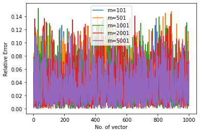

```python
N  = 1000   # Number of vectors
n  = 200    # Reduced space of w

f = plt.figure()
for _g in [101, 501, 1001, 2001, 5001]:    # Loop over a range of dimensions for v_i
    xx = np.linspace(0,1,_g)
    V  = np.array([np.sin(i*np.pi*xx) for i in range(1,N+1)]).T  # Original data
    A  = np.random.randn(n,_g) / np.sqrt(n)                      # The random projection matrix
    W  = A.dot(V)                                                # The projection
    Wt, Vt = W.T, V.T
    Er = np.abs( (np.linalg.norm(Wt-Wt[0], axis=1) / np.linalg.norm(Vt-Vt[0], axis=1))-1 )

    plt.plot(Er, label=f'm={_g}')          # See how the errors are constant on average,
                                           # regardless of dimension of v_i
plt.legend()
plt.xlabel('No. of vector')
_=plt.ylabel('Relative Error')
```